# Tugas Praktikum 1

Shafi Faris Arif Rabbani - G1401231008

2025-08-31

```r
library("forecast")
```

```r
library("graphics")
library("TTR")
library("TSA")
library(rio)
library(ggplot2)
library(dplyr)
library(lubridate)
library(tidyr)
library(readxl)
```

```r
#Import data xlsx
gold <- read_excel("C:/Users/M S I/OneDrive/Documents/Semester 5/MPDW/Praktikum MPDW/MPDW/Pertemuan 1/Gold Price.xlsx")
gold
```

```
## # A tibble: 500 × 2
##    Date                Price
##    <dttm>              <dbl>
##  1 2023-01-25 00:00:00 56865
##  2 2023-01-27 00:00:00 56789
##  3 2023-01-30 00:00:00 56754
##  4 2023-01-31 00:00:00 56864
##  5 2023-02-01 00:00:00 57599
##  6 2023-02-02 00:00:00 57710
##  7 2023-02-03 00:00:00 57424
##  8 2023-02-06 00:00:00 56926
##  9 2023-02-07 00:00:00 57175
## 10 2023-02-08 00:00:00 57128
## # ℹ 490 more rows
```

## Eksplorasi Data

```r
View(gold)
str(gold)
```

```
## tibble [500 × 2] (S3: tbl_df/tbl/data.frame)
##  $ Date : POSIXct[1:500], format: "2023-01-25" "2023-01-27" ...
##  $ Price: num [1:500] 56865 56789 56754 56864 57599 ...
```

```r
dim(gold)
```

```
## [1] 500   2
```

```r
data <- gold[201:300,]
data
```

```
## # A tibble: 100 × 2
##    Date                Price
##    <dttm>              <dbl>
##  1 2023-11-07 00:00:00 60365
##  2 2023-11-08 00:00:00 60043
##  3 2023-11-09 00:00:00 60271
##  4 2023-11-10 00:00:00 59697
##  5 2023-11-12 00:00:00 59785
##  6 2023-11-13 00:00:00 59844
##  7 2023-11-14 00:00:00 60083
##  8 2023-11-15 00:00:00 60120
##  9 2023-11-16 00:00:00 60654
## 10 2023-11-17 00:00:00 60678
## # ℹ 90 more rows
```

```r
data$Date <- as.Date(data$Date)
all_dates <- seq(min(data$Date), max(data$Date), by = "day")
missing_dates <- setdiff(all_dates, data$Date)
missing_dates
```

```
##  [1] "2023-11-11" "2023-11-18" "2023-11-19" "2023-11-25" "2023-11-26"
##  [6] "2023-12-02" "2023-12-03" "2023-12-09" "2023-12-10" "2023-12-16"
## [11] "2023-12-17" "2023-12-23" "2023-12-24" "2023-12-25" "2023-12-30"
## [16] "2023-12-31" "2024-01-06" "2024-01-07" "2024-01-13" "2024-01-14"
## [21] "2024-01-20" "2024-01-21" "2024-01-26" "2024-01-27" "2024-01-28"
## [26] "2024-02-03" "2024-02-04" "2024-02-10" "2024-02-11" "2024-02-17"
## [31] "2024-02-18" "2024-02-24" "2024-02-25" "2024-03-02" "2024-03-03"
## [36] "2024-03-09" "2024-03-10" "2024-03-16" "2024-03-17" "2024-03-23"
## [41] "2024-03-24"
```

Mengubah data agar terbaca sebagai data deret waktu dengan fungsi `ts()` .

```r
data.ts <- ts(data$Price)
data.ts
```

```
## Time Series:
## Start = 1
## End = 100
## Frequency = 1
##   [1] 60365 60043 60271 59697 59785 59844 60083 60120 60654 60678 60657 61212
##  [13] 61065 61093 61352 61557 62409 62470 62639 62876 62302 62600 62269 62290
##  [25] 61597 60986 60984 60992 62229 61991 62057 62211 62151 62257 62657 62722
##  [37] 63292 63119 62954 63001 63039 62294 62444 62627 62140 62211 62047 61830
##  [49] 62372 62567 62065 61561 61791 62021 61888 62003 62072 62036 62234 62371
##  [61] 62865 63079 62639 62542 62322 62305 62219 62105 61856 61267 61170 61306
##  [73] 61498 61641 61810 61744 61661 61910 61766 61839 61792 62293 63135 63605
##  [85] 64193 65042 65246 65847 65872 65334 65717 65435 65367 65429 65431 65556
##  [97] 65939 65686 65862 66027
```

```r
#buatkan frekuensi mingguan
gold.ts <- ts(data$Price, frequency = 7)
gold.ts
```

```
## Time Series:
## Start = c(1, 1)
## End = c(15, 2)
## Frequency = 7
##   [1] 60365 60043 60271 59697 59785 59844 60083 60120 60654 60678 60657 61212
##  [13] 61065 61093 61352 61557 62409 62470 62639 62876 62302 62600 62269 62290
##  [25] 61597 60986 60984 60992 62229 61991 62057 62211 62151 62257 62657 62722
##  [37] 63292 63119 62954 63001 63039 62294 62444 62627 62140 62211 62047 61830
##  [49] 62372 62567 62065 61561 61791 62021 61888 62003 62072 62036 62234 62371
##  [61] 62865 63079 62639 62542 62322 62305 62219 62105 61856 61267 61170 61306
##  [73] 61498 61641 61810 61744 61661 61910 61766 61839 61792 62293 63135 63605
##  [85] 64193 65042 65246 65847 65872 65334 65717 65435 65367 65429 65431 65556
##  [97] 65939 65686 65862 66027
```

Menampilkan ringkasan data

```r
summary(gold.ts)
```

```
##    Min. 1st Qu.  Median    Mean 3rd Qu.    Max.
##   59697   61630   62215   62455   62868   66027
```

Membuat plot data deret waktu

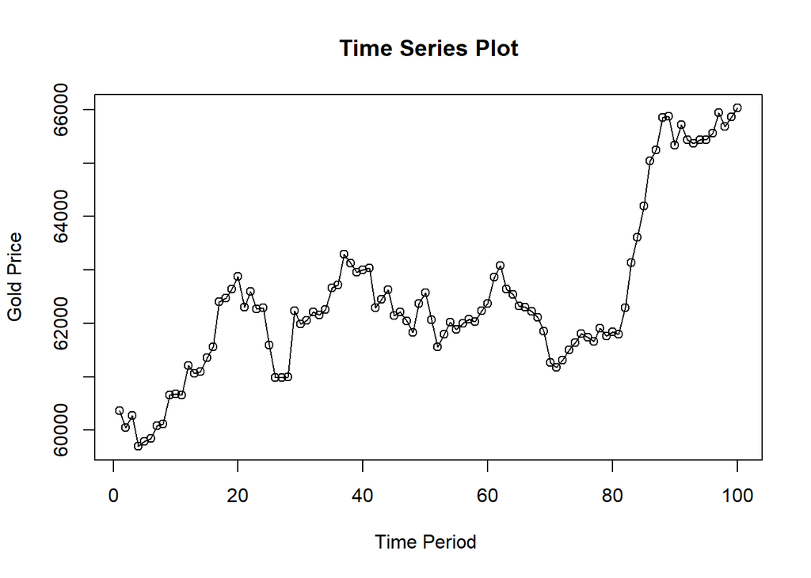

```r
ts.plot(data.ts, xlab="Time Period ", ylab="Gold Price",
        main = "Time Series Plot")
points(data.ts)
```

## Single Moving Average & Double Moving Average

### Pembagian Data

Pembagian data latih dan data uji dilakukan dengan perbandingan 80% data latih dan 20% data uji.

```r
# hitung jumlah data
n <- nrow(data)

# tentukan batas 80%
n_train <- floor(0.8 * n)

# bagi data
training_ma <- data[1:n_train, ]
testing_ma  <- data[(n_train+1):n, ]

# ubah ke time series
train_ma.ts <- ts(training_ma$Price)
test_ma.ts  <- ts(testing_ma$Price)
```

Eksplorasi data dilakukan pada keseluruhan data, data latih serta data uji menggunakan plot data deret waktu.

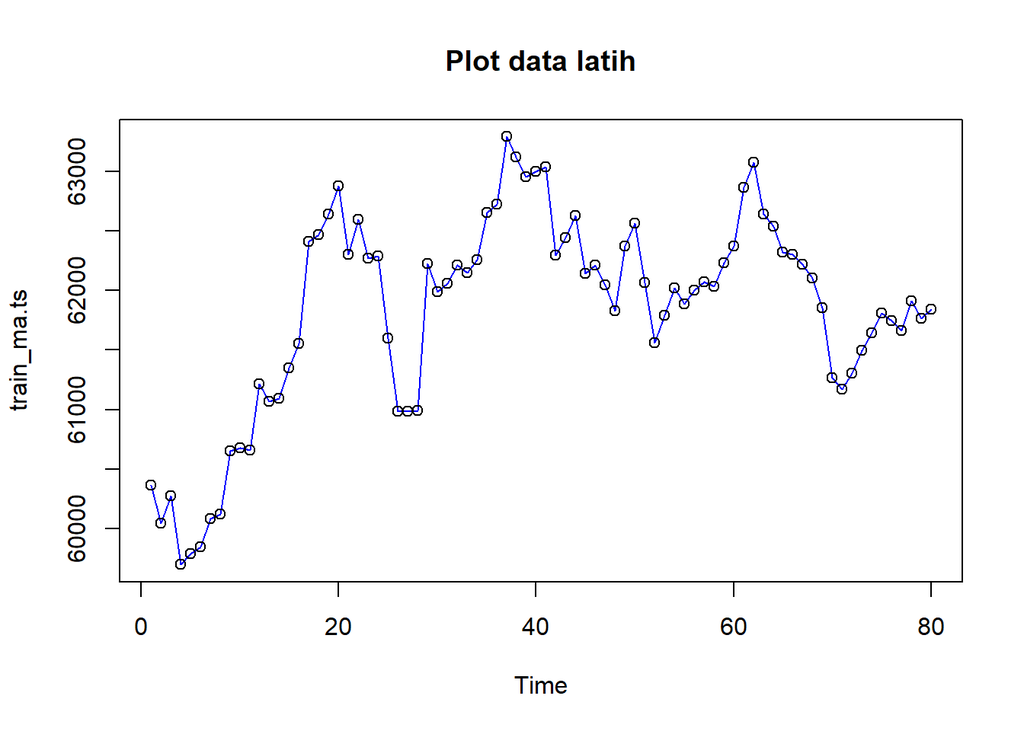

```r
#eksplorasi data latih
plot(train_ma.ts, col="blue",main="Plot data latih")
points(train_ma.ts)
```

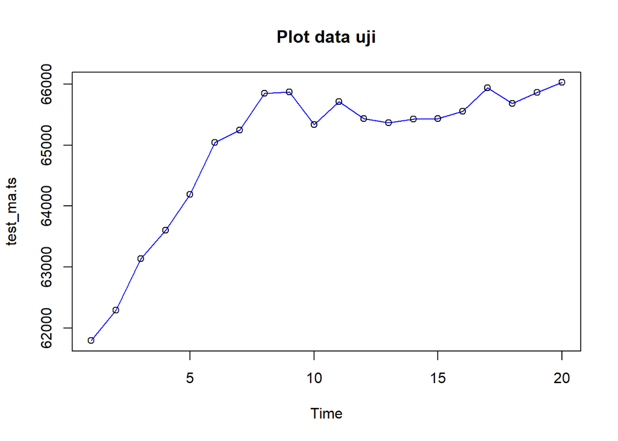

```r
#eksplorasi data uji
plot(test_ma.ts, col="blue",main="Plot data uji")
points(test_ma.ts)
```

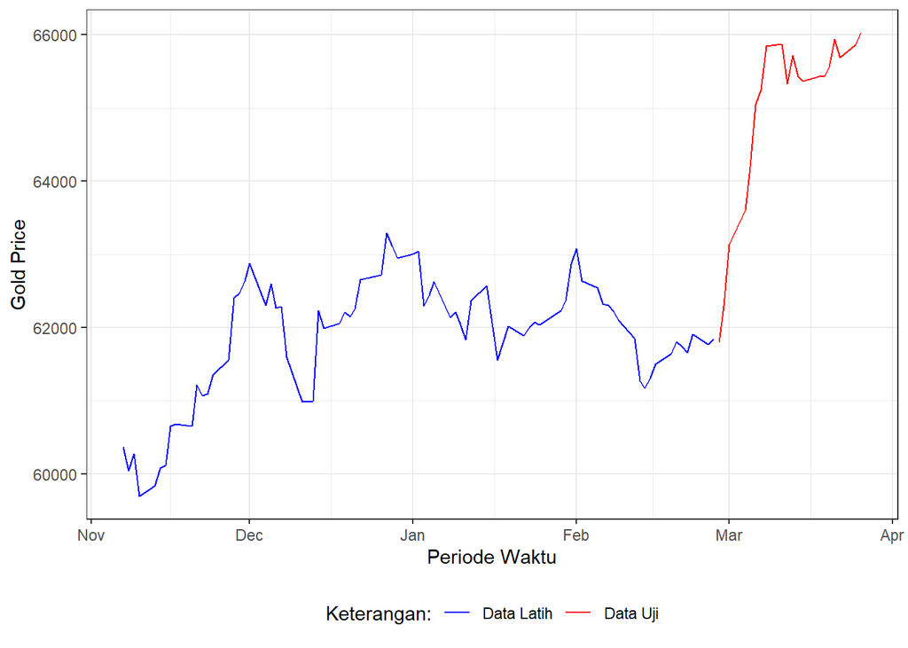

```r
library(ggplot2)
ggplot() +
  geom_line(data = training_ma, aes(x = Date, y = Price, col = "Data Latih")) +
  geom_line(data = testing_ma, aes(x = Date, y = Price, col = "Data Uji")) +
  labs(x = "Periode Waktu", y = "Gold Price", color = "Legend") +
   scale_colour_manual(name="Keterangan:", breaks = c("Data Latih", "Data Uji"),
                      values = c("blue", "red")) +
  theme_bw() + theme(legend.position = "bottom",
                     plot.caption = element_text(hjust=0.5, size=12))
```

### Single Moving Average (SMA)

Pemulusan menggunakan metode SMA dilakukan dengan fungsi `SMA()`. Dalam hal ini akan dilakukan pemulusan dengan parameter `m=4`.

```r
data.sma<-SMA(train_ma.ts, n=4)
data.sma
```

```
## Time Series:
## Start = 1
## End = 80
## Frequency = 1
##  [1]       NA       NA       NA 60094.00 59949.00 59899.25 59852.25 59958.00
##  [9] 60175.25 60383.75 60527.25 60800.25 60903.00 61006.75 61180.50 61266.75
## [17] 61602.75 61947.00 62268.75 62598.50 62571.75 62604.25 62511.75 62365.25
## [25] 62189.00 61785.50 61464.25 61139.75 61297.75 61549.00 61817.25 62122.00
## [33] 62102.50 62169.00 62319.00 62446.75 62732.00 62947.50 63021.75 63091.50
## [41] 63028.25 62822.00 62694.50 62601.00 62376.25 62355.50 62256.25 62057.00
## [49] 62115.00 62204.00 62208.50 62141.25 61996.00 61859.50 61815.25 61925.75
## [57] 61996.00 61999.75 62086.25 62178.25 62376.50 62637.25 62738.50 62781.25
## [65] 62645.50 62452.00 62347.00 62237.75 62121.25 61861.75 61599.50 61399.75
## [73] 61310.25 61403.75 61563.75 61673.25 61714.00 61781.25 61770.25 61794.00
```

Data pemulusan pada periode ke-t selanjutnya digunakan sebagai nilai peramalan pada periode ke t+1 sehingga hasil peramalan 1 periode kedepan adalah sebagai berikut.

```r
data.ramal<-c(NA,data.sma)
data.ramal #forecast 1 periode ke depan
```

```
##  [1]       NA       NA       NA       NA 60094.00 59949.00 59899.25 59852.25
##  [9] 59958.00 60175.25 60383.75 60527.25 60800.25 60903.00 61006.75 61180.50
## [17] 61266.75 61602.75 61947.00 62268.75 62598.50 62571.75 62604.25 62511.75
## [25] 62365.25 62189.00 61785.50 61464.25 61139.75 61297.75 61549.00 61817.25
## [33] 62122.00 62102.50 62169.00 62319.00 62446.75 62732.00 62947.50 63021.75
## [41] 63091.50 63028.25 62822.00 62694.50 62601.00 62376.25 62355.50 62256.25
## [49] 62057.00 62115.00 62204.00 62208.50 62141.25 61996.00 61859.50 61815.25
## [57] 61925.75 61996.00 61999.75 62086.25 62178.25 62376.50 62637.25 62738.50
## [65] 62781.25 62645.50 62452.00 62347.00 62237.75 62121.25 61861.75 61599.50
## [73] 61399.75 61310.25 61403.75 61563.75 61673.25 61714.00 61781.25 61770.25
## [81] 61794.00
```

```r
data.gab<-cbind(
  aktual=c(data.ts),
  pemulusan=c(data.sma,rep(NA,24)),
  ramalan=c(data.ramal,rep(data.ramal[length(data.ramal)],23)))
data.gab #forecast 24 periode ke depan
```

```
##        aktual pemulusan  ramalan
##   [1,]  60365        NA       NA
##   [2,]  60043        NA       NA
##   [3,]  60271        NA       NA
##   [4,]  59697  60094.00       NA
##   [5,]  59785  59949.00 60094.00
##   [6,]  59844  59899.25 59949.00
##   [7,]  60083  59852.25 59899.25
##   [8,]  60120  59958.00 59852.25
##   [9,]  60654  60175.25 59958.00
##  [10,]  60678  60383.75 60175.25
##  [11,]  60657  60527.25 60383.75
##  [12,]  61212  60800.25 60527.25
##  [13,]  61065  60903.00 60800.25
##  [14,]  61093  61006.75 60903.00
```

[output cut: 90 more lines]

Adapun plot data deret waktu dari hasil peramalan yang dilakukan adalah sebagai berikut.

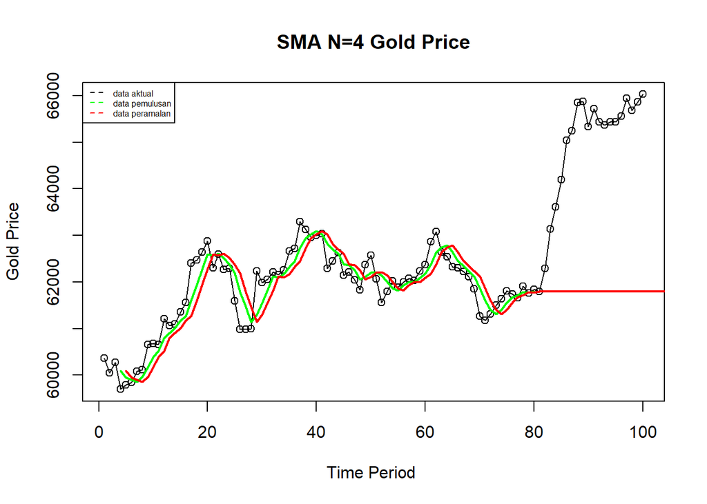

```r
ts.plot(data.ts, xlab="Time Period ", ylab="Gold Price", main= "SMA N=4 Gold Price")
points(data.ts)
lines(data.gab[,2],col="green",lwd=2)
lines(data.gab[,3],col="red",lwd=2)
legend("topleft",c("data aktual","data pemulusan","data peramalan"), lty=8, col=c("black","green","red"), cex=0.5)
```

Selanjutnya perhitungan akurasi dilakukan dengan ukuran akurasi *Sum Squares Error* (SSE), *Mean Square Error* (MSE) dan *Mean Absolute Percentage Error* (MAPE). Perhitungan akurasi dilakukan baik pada data latih maupun pada data uji.

```r
#Menghitung nilai keakuratan data latih
error_train.sma = train_ma.ts-data.ramal[1:length(train_ma.ts)]

SSE_train.sma = sum(error_train.sma[5:length(train_ma.ts)]^2)
MSE_train.sma = mean(error_train.sma[5:length(train_ma.ts)]^2)
MAPE_train.sma = mean(abs((error_train.sma[5:length(train_ma.ts)]/train_ma.ts[5:length(train_ma.ts)])*100))

akurasi_train.sma <- matrix(c(SSE_train.sma, MSE_train.sma, MAPE_train.sma))
row.names(akurasi_train.sma)<- c("SSE", "MSE", "MAPE")
colnames(akurasi_train.sma) <- c("Akurasi m = 4")
akurasi_train.sma
```

```
##      Akurasi m = 4
## SSE   1.679764e+07
## MSE   2.210216e+05
## MAPE  6.055227e-01
```

Dalam hal ini nilai MAPE data latih pada metode pemulusan SMA sekitar 0.61%. Artinya, sangat akurat dalam memprediksi data latih. Kesalahan prediksinya sangat kecil, sehingga model ini dapat dipercaya untuk merepresentasikan pola historis pada data latih.

```r
# Menghitung nilai keakuratan data Test
# Ambil data aktual (baris 81-104, kolom 1)
actual_test <- data.gab[81:104, 1]

# Ambil data ramalan (baris 81-104, kolom 3)
forecast_test <- data.gab[81:104, 3]

# Hitung error
error_test.sma <- actual_test - forecast_test

# Hitung metrik
SSE_test.sma <- sum(error_test.sma^2)
MSE_test.sma <- mean(error_test.sma^2)
MAPE_test.sma <- mean(abs(error_test.sma / actual_test * 100))

akurasi_test.sma <- matrix(c(SSE_test.sma, MSE_test.sma, MAPE_test.sma))
row.names(akurasi_test.sma)<- c("SSE", "MSE", "MAPE")
colnames(akurasi_test.sma) <- c("Akurasi m = 4")
akurasi_test.sma
```

```
##      Akurasi m = 4
## SSE   2.397639e+08
## MSE   9.990161e+06
## MAPE  4.480672e+00
```

Perhitungan akurasi menggunakan data latih menghasilkan nilai MAPE yang kurang dari 10% sehingga nilai akurasi ini dapat dikategorikan sebagai sangat baik.

### Double Moving Average (DMA)

Metode pemulusan Double Moving Average (DMA) pada dasarnya mirip dengan SMA. Namun demikian, metode ini lebih cocok digunakan untuk pola data trend. Proses pemulusan dengan rata rata dalam metode ini dilakukan sebanyak 2 kali.

```r
dma <- SMA(data.sma, n = 4)
At <- 2*data.sma - dma
Bt <- 2/(4-1)*(data.sma - dma)
data.dma<- At+Bt
data.ramal2<- c(NA, data.dma)

t = 1:24
f = c()

for (i in t) {
  f[i] = At[length(At)] + Bt[length(Bt)]*(i)
}

data.gab2 <- cbind(aktual = c(data.ts),
                   pemulusan1 = c(data.sma,rep(NA,24)),
                   pemulusan2 = c(dma, rep(NA,24)),
                   At = c(At, rep(NA,24)),
                   Bt = c(Bt,rep(NA,24)),
                   ramalan = c(data.ramal2, f[-1]))
data.gab2
```

```
##        aktual pemulusan1 pemulusan2       At         Bt  ramalan
##   [1,]  60365         NA         NA       NA         NA       NA
##   [2,]  60043         NA         NA       NA         NA       NA
##   [3,]  60271         NA         NA       NA         NA       NA
##   [4,]  59697   60094.00         NA       NA         NA       NA
##   [5,]  59785   59949.00         NA       NA         NA       NA
##   [6,]  59844   59899.25         NA       NA         NA       NA
##   [7,]  60083   59852.25   59948.62 59755.88  -64.25000       NA
##   [8,]  60120   59958.00   59914.62 60001.38   28.91667 59691.62
##   [9,]  60654   60175.25   59971.19 60379.31  136.04167 60030.29
##  [10,]  60678   60383.75   60092.31 60675.19  194.29167 60515.35
##  [11,]  60657   60527.25   60261.06 60793.44  177.45833 60869.48
##  [12,]  61212   60800.25   60471.62 61128.88  219.08333 60970.90
##  [13,]  61065   60903.00   60653.56 61152.44  166.29167 61347.96
##  [14,]  61093   61006.75   60809.31 61204.19  131.62500 61318.73
```

[output cut: 90 more lines]

Hasil pemulusan menggunakan metode DMA divisualisasikan sebagai berikut

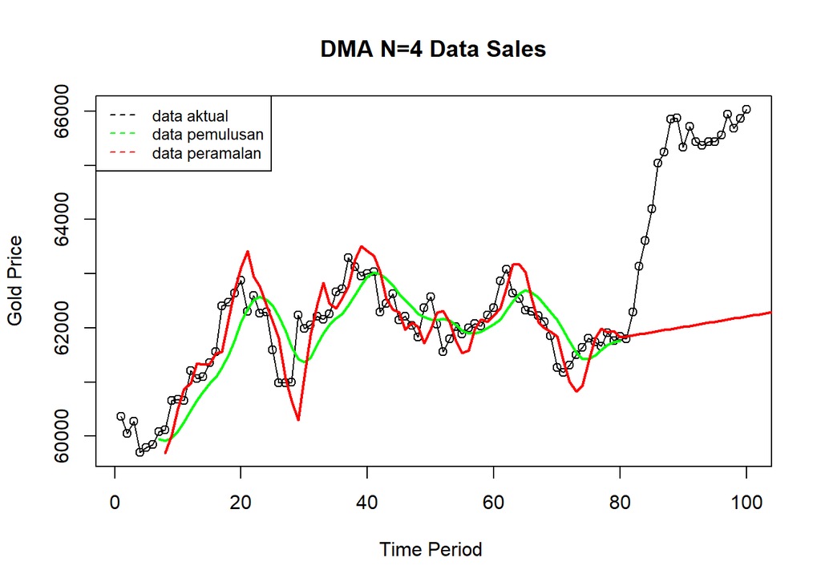

```r
ts.plot(data.ts, xlab="Time Period ", ylab="Gold Price", main= "DMA N=4 Data Sales")
points(data.ts)
lines(data.gab2[,3],col="green",lwd=2)
lines(data.gab2[,6],col="red",lwd=2)
legend("topleft",c("data aktual","data pemulusan","data peramalan"), lty=8, col=c("black","green","red"), cex=0.8)
```

Selanjutnya perhitungan akurasi dilakukan baik pada data latih maupun data uji. Perhitungan akurasi dilakukan dengan ukuran akurasi SSE, MSE dan MAPE.

```r
#Menghitung nilai keakuratan data latih
error_train.dma = train_ma.ts-data.ramal2[1:length(train_ma.ts)]

SSE_train.dma = sum(error_train.dma[8:length(train_ma.ts)]^2)
MSE_train.dma = mean(error_train.dma[8:length(train_ma.ts)]^2)
MAPE_train.dma = mean(abs((error_train.dma[8:length(train_ma.ts)]/train_ma.ts[8:length(train_ma.ts)])*100))

akurasi_train.dma <- matrix(c(SSE_train.dma, MSE_train.dma, MAPE_train.dma))
row.names(akurasi_train.dma)<- c("SSE", "MSE", "MAPE")
colnames(akurasi_train.dma) <- c("Akurasi m = 4")
akurasi_train.dma
```

```
##      Akurasi m = 4
## SSE   1.657221e+07
## MSE   2.270166e+05
## MAPE  5.867543e-01
```

Nilai MAPE sebesar 0,59% menunjukkan bahwa rata-rata kesalahan prediksi model DMA (m=4) terhadap data latih hanya sekitar 0,59% dari nilai aktual. Dengan nilai yang jauh di bawah 10%, akurasi model dapat dikategorikan sangat baik. Hal ini berarti model DMA mampu merepresentasikan pola data latih dengan tingkat kesalahan yang sangat rendah sehingga layak digunakan sebagai dasar peramalan.

```r
# Menghitung nilai keakuratan data uji
# Ambil data aktual (baris 81-104, kolom 1)
actual_test <- data.gab2[81:104, 1]

# Ambil data ramalan (baris 81-104, kolom 3)
forecast_test <- data.gab2[81:104, 6]

# Hitung error
error_test.dma <- actual_test - forecast_test
SSE_test.dma = sum(error_test.dma^2)
MSE_test.dma = mean(error_test.dma^2)
MAPE_test.dma <- mean(abs(error_test.dma / actual_test * 100))

# Menyusun matriks hasil akurasi
akurasi_test.dma <- matrix(c(SSE_test.dma, MSE_test.dma, MAPE_test.dma))
row.names(akurasi_test.dma)<- c("SSE", "MSE", "MAPE")
colnames(akurasi_test.dma) <- c("Akurasi m = 4")
akurasi_test.dma
```

```
##      Akurasi m = 4
## SSE   2.146266e+08
## MSE   8.942775e+06
## MAPE  4.319602e+00
```

MAPE sebesar 4,32% menunjukkan bahwa rata-rata kesalahan prediksi model pada data uji adalah sekitar 4,32% dari nilai aktual. Nilai ini masih berada di bawah 10%, sehingga model DMA (m=4) dapat dikategorikan memiliki akurasi yang baik. Artinya, meskipun pada data uji model tidak seakurat pada data latih (MAPE 0,59%), hasil peramalan tetap cukup reliabel dan dapat digunakan sebagai acuan prediksi.

Pada data latih, metode DMA lebih baik dibandingkan dengan metode DMA, begitu pula pada data uji, metode DMA juga lebih baik dibandingkan SMA.

## Single Exponential Smoothing & Double Exponential Smoothing

### Pembagian Data

Pembagian data latih dan data uji dilakukan dengan perbandingan 80% data latih dan 20% data uji.

```r
# jumlah baris data
n <- nrow(data)

# hitung batas 80%
n_train <- floor(0.8 * n)

# bagi data
training <- data[1:n_train, ]
testing  <- data[(n_train+1):n, ]

# ubah ke time series
train.ts <- ts(training$Price)
test.ts  <- ts(testing$Price)
```

### Eksplorasi

Eksplorasi dilakukan dengan membuat plot data deret waktu untuk keseluruhan data, data latih, dan data uji.

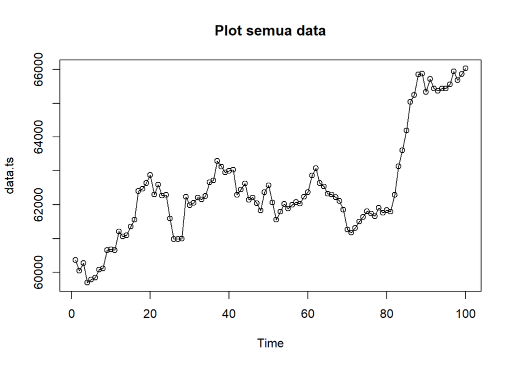

```r
#eksplorasi data
plot(data.ts, col="black",main="Plot semua data")
points(data.ts)
```

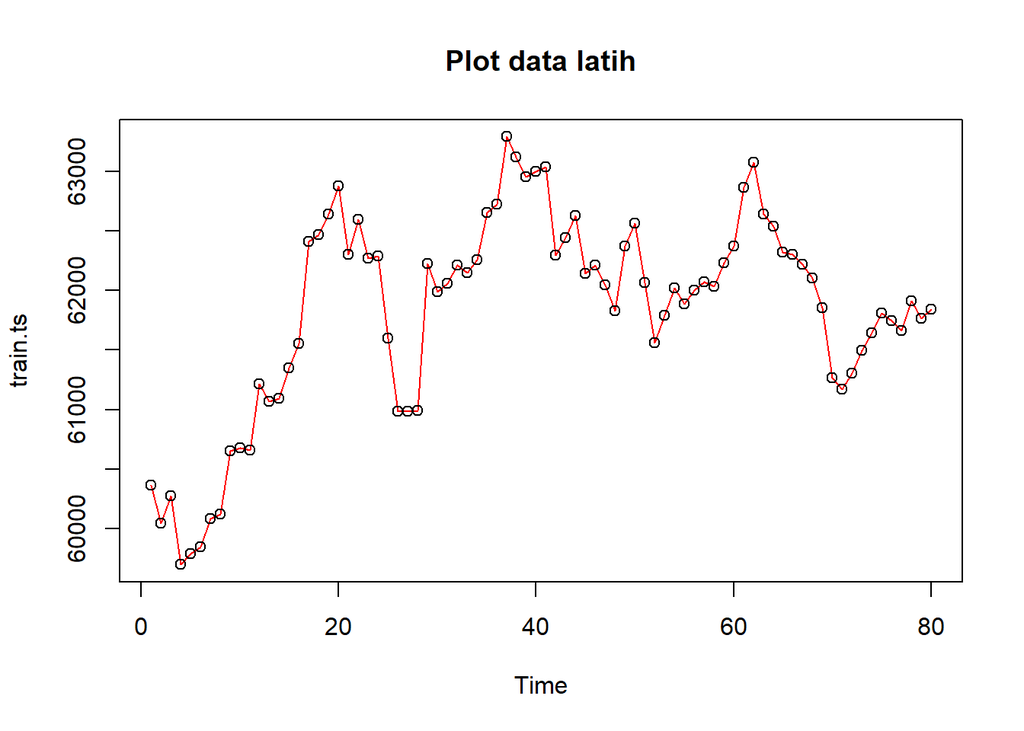

```r
plot(train.ts, col="red",main="Plot data latih")
points(train.ts)
```

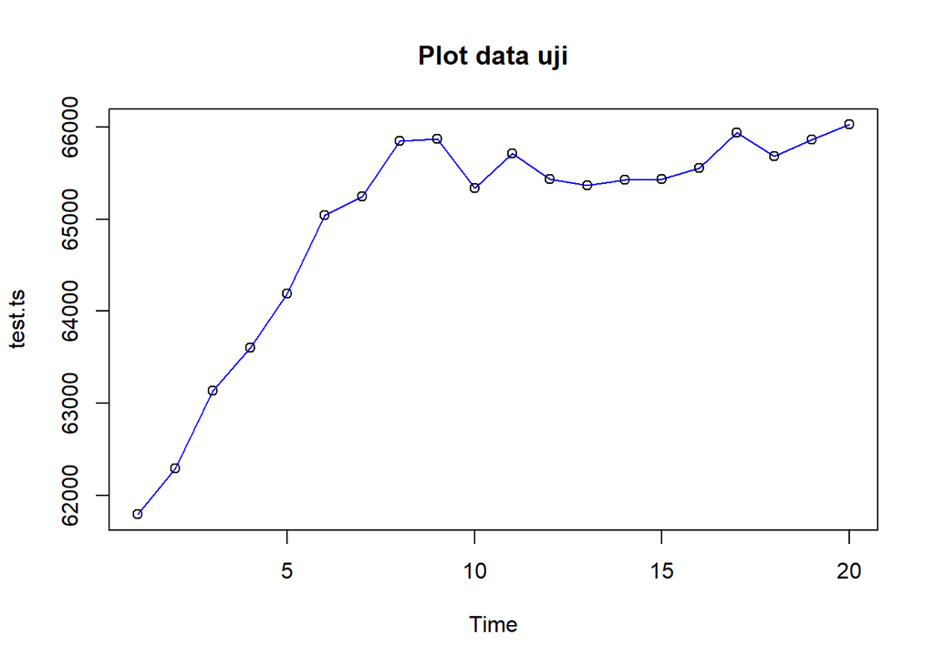

```r
plot(test.ts, col="blue",main="Plot data uji")
points(test.ts)
```

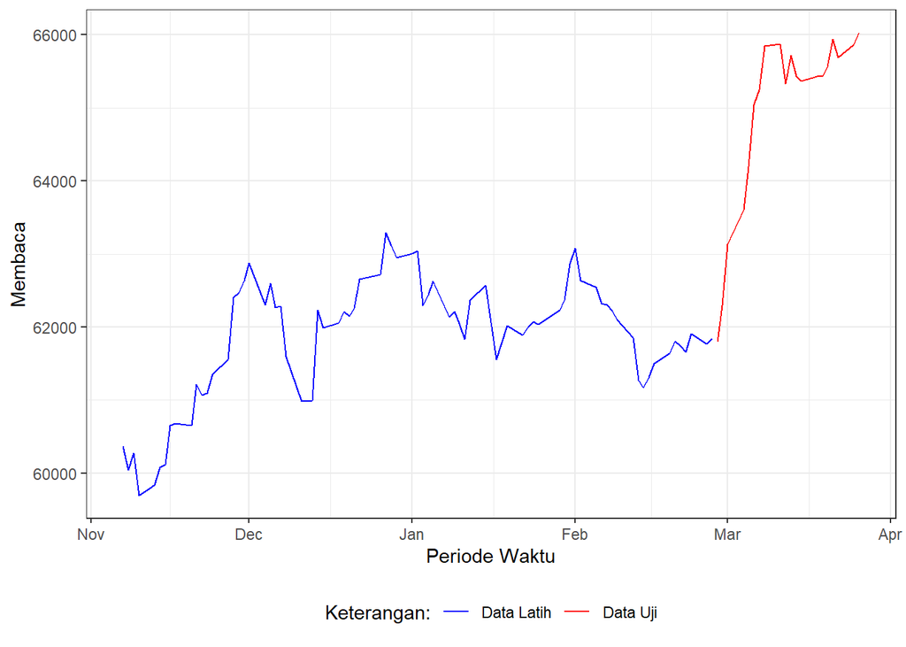

```r
#Eksplorasi dengan GGPLOT
library(ggplot2)
ggplot() +
  geom_line(data = training, aes(x = Date, y = Price, col = "Data Latih")) +
  geom_line(data = testing, aes(x = Date, y = Price, col = "Data Uji")) +
  labs(x = "Periode Waktu", y = "Membaca", color = "Legend") +
  scale_colour_manual(name="Keterangan:", breaks = c("Data Latih", "Data Uji"),
                      values = c("blue", "red")) +
  theme_bw() + theme(legend.position = "bottom",
                     plot.caption = element_text(hjust=0.5, size=12))
```

## Single Exponential Smoothing

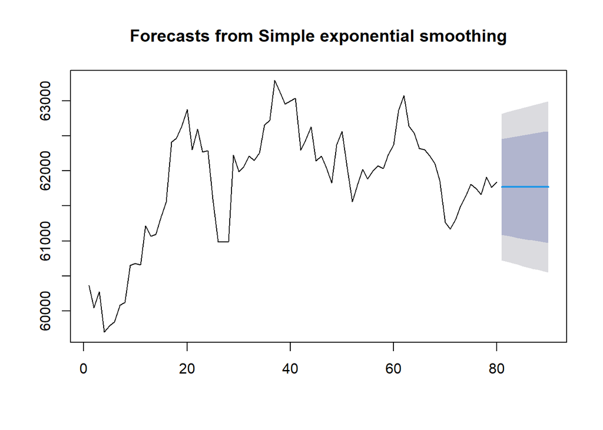

```r
#Cara 1 (fungsi ses)
ses.1 <- ses(train.ts, h = 10, alpha = 0.2)
plot(ses.1)
```

Grafik SES menunjukkan bahwa hasil peramalan (garis biru) cenderung datar mengikuti pola rata-rata data terakhir, sementara area bayangan abu-abu menunjukkan ketidakpastian yang makin besar ke depan. Model ini baik untuk data stabil, tetapi kurang mampu menangkap tren naik atau turun tajam.

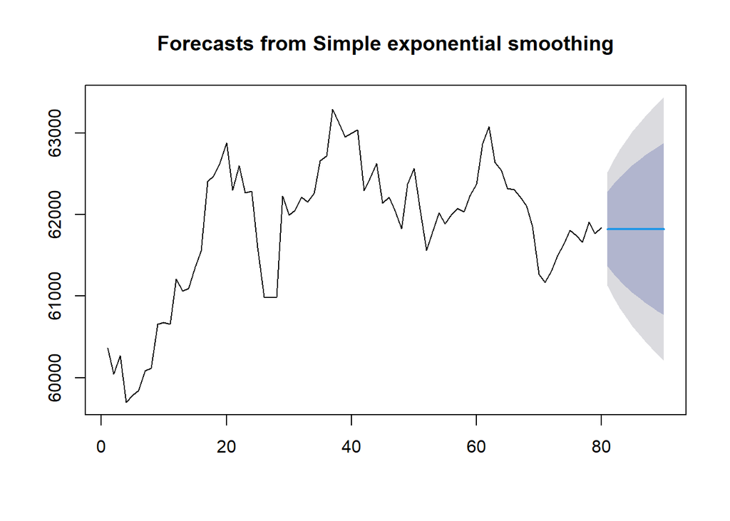

```r
ses.2 <- ses(train.ts, h = 10, alpha = 0.7)
plot(ses.2)
```

Untuk mendapatkan gambar hasil pemulusan pada data latih dengan fungsi `ses()` , perlu digunakan fungsi `autoplot()` dan `autolayer()` dari *library packages* `ggplot2` .

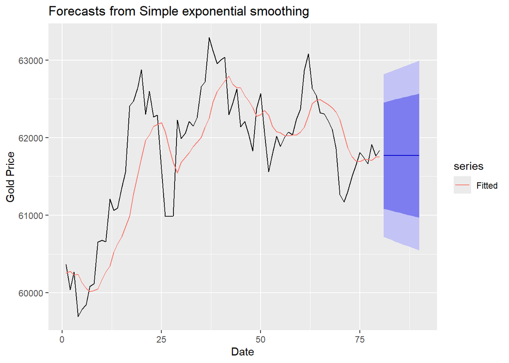

```r
autoplot(ses.1) +
  autolayer(fitted(ses.1), series="Fitted") +
  ylab("Gold Price") + xlab("Date")
```

Model SES ini mampu memberikan peramalan yang relatif stabil dengan mengikuti tren rata-rata data terakhir.

Selanjutnya akan digunakan fungsi `HoltWinters()` dengan nilai inisialisasi parameter dan panjang periode peramalan yang sama dengan fungsi `ses()` .

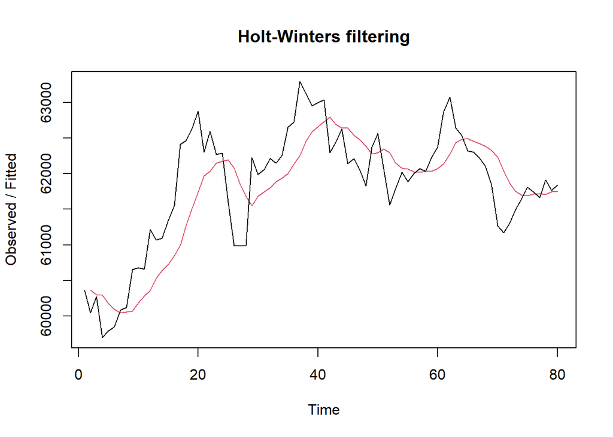

```r
#Cara 2 (fungsi Holtwinter)
ses1<- HoltWinters(train.ts, gamma = FALSE, beta = FALSE, alpha = 0.2)
plot(ses1)
```

```r
#ramalan
ramalan1<- forecast(ses1, h=10)
ramalan1
```

```
##    Point Forecast    Lo 80    Hi 80    Lo 95    Hi 95
## 81       61769.69 61094.12 62445.27 60736.49 62802.90
## 82       61769.69 61080.74 62458.65 60716.03 62823.36
## 83       61769.69 61067.61 62471.77 60695.96 62843.43
## 84       61769.69 61054.73 62484.65 60676.25 62863.13
## 85       61769.69 61042.08 62497.31 60656.90 62882.49
## 86       61769.69 61029.64 62509.75 60637.87 62901.51
## 87       61769.69 61017.40 62521.98 60619.17 62920.22
## 88       61769.69 61005.37 62534.02 60600.76 62938.63
## 89       61769.69 60993.52 62545.87 60582.63 62956.75
## 90       61769.69 60981.84 62557.54 60564.78 62974.60
```

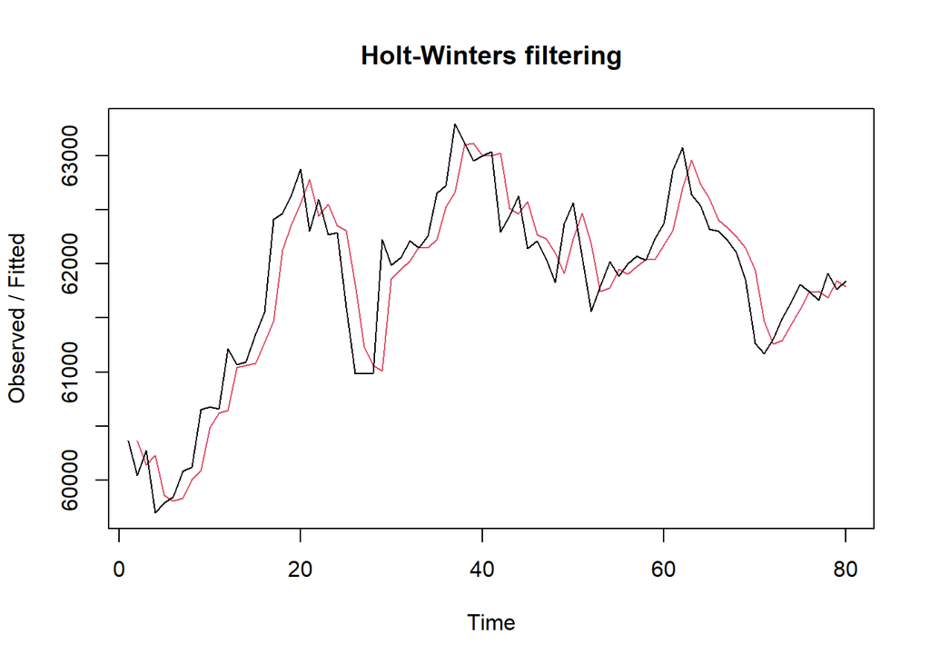

```r
ses2<- HoltWinters(train.ts, gamma = FALSE, beta = FALSE, alpha = 0.7)
plot(ses2)
```

```r
#ramalan
ramalan2<- forecast(ses2, h=10)
ramalan2
```

```
##    Point Forecast    Lo 80    Hi 80    Lo 95    Hi 95
## 81          61824 61372.09 62275.92 61132.86 62515.15
## 82          61824 61272.37 62375.63 60980.35 62667.65
## 83          61824 61188.10 62459.90 60851.48 62796.53
## 84          61824 61113.76 62534.24 60737.78 62910.22
## 85          61824 61046.50 62601.50 60634.91 63013.09
## 86          61824 60984.61 62663.40 60540.26 63107.74
## 87          61824 60926.98 62721.03 60452.12 63195.88
## 88          61824 60872.83 62775.17 60369.31 63278.69
## 89          61824 60821.61 62826.40 60290.97 63357.03
## 90          61824 60772.88 62875.13 60216.44 63431.56
```

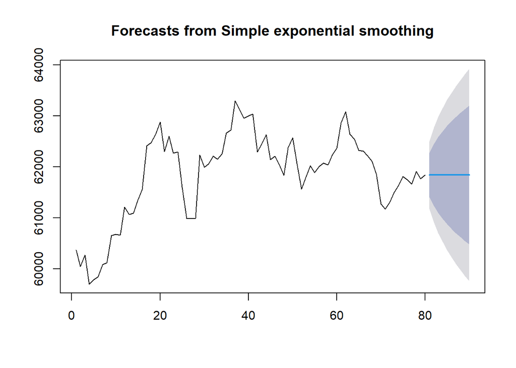

```r
#SES
ses.opt <- ses(train.ts, h = 10, alpha = NULL)
plot(ses.opt)
```

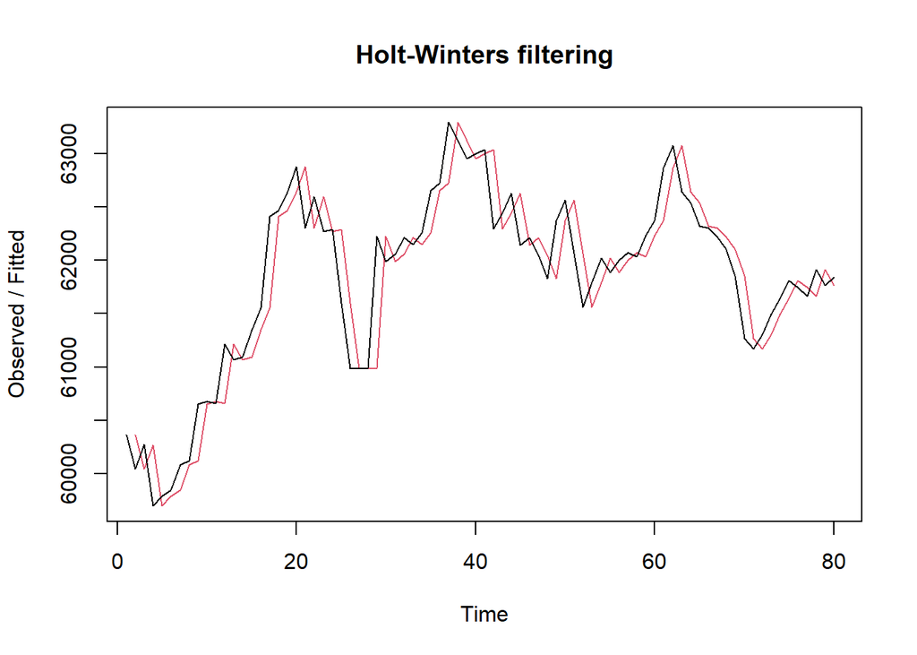

```r
#Lamda Optimum Holt Winter
HWopt<- HoltWinters(train.ts, gamma = FALSE, beta = FALSE,alpha = NULL)
plot(HWopt)
```

```r
#ramalan
ramalanopt<- forecast(HWopt, h=10)
ramalanopt
```

```
##    Point Forecast    Lo 80    Hi 80    Lo 95    Hi 95
## 81       61838.97 61409.04 62268.91 61181.44 62496.50
## 82       61838.97 61231.07 62446.87 60909.27 62768.67
## 83       61838.97 61094.50 62583.44 60700.40 62977.54
## 84       61838.97 60979.36 62698.58 60524.31 63153.64
## 85       61838.97 60877.91 62800.03 60369.16 63308.78
## 86       61838.97 60786.20 62891.74 60228.89 63449.05
## 87       61838.97 60701.86 62976.08 60099.91 63578.04
## 88       61838.97 60623.35 63054.59 59979.85 63698.10
## 89       61838.97 60549.62 63128.32 59867.08 63810.86
## 90       61838.97 60479.88 63198.06 59760.43 63917.52
```

Setelah dilakukan peramalan, akan dilakukan perhitungan keakuratan hasil peramalan. Perhitungan akurasi ini dilakukan baik pada data latih dan data uji.

#### Akurasi Data Latih

```r
#Keakuratan Metode
#Pada data training

# SES dengan alpha = 0.2
SSE1<-ses1$SSE
MSE1<-ses1$SSE/length(train.ts)
RMSE1<-sqrt(MSE1)

akurasi1 <- matrix(c(SSE1,MSE1,RMSE1))
row.names(akurasi1)<- c("SSE", "MSE", "RMSE")
colnames(akurasi1) <- c("Akurasi lamda=0.2")
akurasi1
```

```
##      Akurasi lamda=0.2
## SSE       2.229996e+07
## MSE       2.787494e+05
## RMSE      5.279673e+02
```

```r
# SES dengan alpha = 0.7
SSE2<-ses2$SSE
MSE2<-ses2$SSE/length(train.ts)
RMSE2<-sqrt(MSE2)

akurasi2 <- matrix(c(SSE2,MSE2,RMSE2))
row.names(akurasi2)<- c("SSE", "MSE", "RMSE")
colnames(akurasi2) <- c("Akurasi lamda=0.7")
akurasi2
```

```
##      Akurasi lamda=0.7
## SSE       9754163.7909
## MSE        121927.0474
## RMSE          349.1805
```

#### Akurasi Data Uji

Akurasi data uji dapat dihitung dengan cara yang hampir sama dengan perhitungan akurasi data latih.

```r
# jumlah observasi uji
n_test <- nrow(testing)

# error (ramalan - aktual), samakan panjang dan tipe numeric
e1   <- as.numeric(ramalan1$mean)[1:n_test] - as.numeric(testing$Price)
e2   <- as.numeric(ramalan2$mean)[1:n_test] - as.numeric(testing$Price)
eopt <- as.numeric(ramalanopt$mean)[1:n_test] - as.numeric(testing$Price)

# SSE / MSE / RMSE untuk masing-masing model (abaikan NA)
SSEtesting1  <- sum(e1^2,  na.rm = TRUE)
MSEtesting1  <- mean(e1^2, na.rm = TRUE)
RMSEtesting1 <- sqrt(MSEtesting1)

SSEtesting2  <- sum(e2^2,  na.rm = TRUE)
MSEtesting2  <- mean(e2^2, na.rm = TRUE)
RMSEtesting2 <- sqrt(MSEtesting2)

SSEtestingopt  <- sum(eopt^2,  na.rm = TRUE)
MSEtestingopt  <- mean(eopt^2, na.rm = TRUE)
RMSEtestingopt <- sqrt(MSEtestingopt)

# Tabel ringkas
akurasitesting_SSE <- matrix(c(SSEtesting1, SSEtesting2, SSEtestingopt),
                             nrow = 3,
                             dimnames = list(c("SSE1","SSE2","SSEopt"), "Nilai"))
akurasitesting_MSE <- matrix(c(MSEtesting1, MSEtesting2, MSEtestingopt),
                             nrow = 3,
                             dimnames = list(c("MSE1","MSE2","MSEopt"), "Nilai"))
akurasitesting_RMSE <- matrix(c(RMSEtesting1, RMSEtesting2, RMSEtestingopt),
                              nrow = 3,
                              dimnames = list(c("RMSE1","RMSE2","RMSEopt"), "Nilai"))

akurasitesting_SSE
```

```
##           Nilai
## SSE1   80329564
## SSE2   77680287
## SSEopt 76960438
```

```r
akurasitesting_MSE
```

```
##          Nilai
## MSE1   8032956
## MSE2   7768029
## MSEopt 7696044
```

```r
akurasitesting_RMSE
```

```
##            Nilai
## RMSE1   2834.247
## RMSE2   2787.118
## RMSEopt 2774.174
```

Berdasarkan hasil perhitungan akurasi pada data uji, model SES dengan alpha optimum memberikan nilai SSE, MSE, dan RMSE terendah dibandingkan dengan model SES dengan alpha tetap (0.2 dan 0.7). Hal ini menunjukkan bahwa model dengan alpha optimum memiliki performa terbaik dalam memprediksi data uji, menghasilkan kesalahan prediksi yang paling kecil di antara ketiga model yang diuji.

## *Double Exponential Smoothing* (DES)

Pemulusan dengan metode DES kali ini akan menggunakan fungsi `HoltWinters()` . Jika sebelumnya nilai argumen `beta` dibuat `FALSE` , kali ini argumen tersebut akan diinisialisasi bersamaan dengan nilai `alpha` .

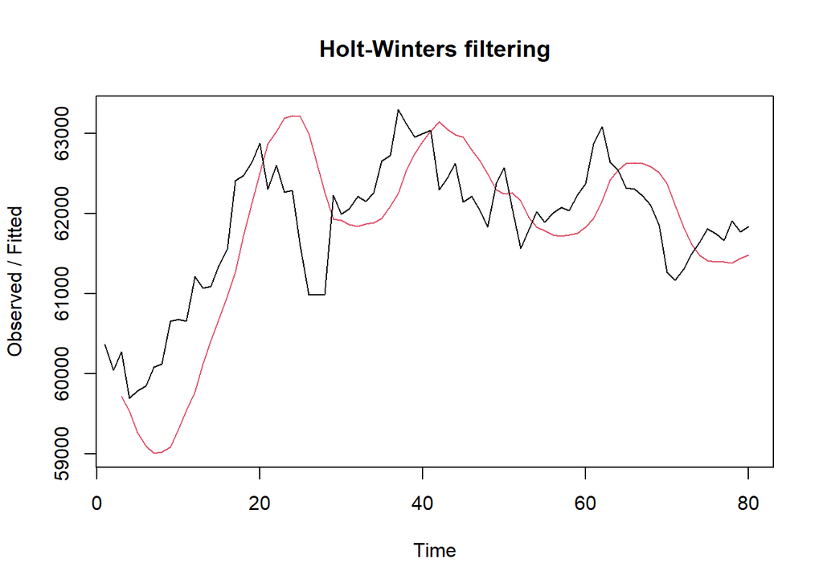

```r
#Lamda=0.2 dan gamma=0.2
des.1<- HoltWinters(train.ts, gamma = FALSE, beta = 0.2, alpha = 0.2)
plot(des.1)
```

```r
#ramalan
ramalandes1<- forecast(des.1, h=10)
ramalandes1
```

```
##    Point Forecast    Lo 80    Hi 80    Lo 95    Hi 95
## 81       61532.06 60591.87 62472.24 60094.17 62969.94
## 82       61515.46 60548.58 62482.34 60036.74 62994.17
## 83       61498.86 60496.78 62500.94 59966.31 63031.40
## 84       61482.26 60435.99 62528.53 59882.13 63082.39
## 85       61465.66 60366.01 62565.31 59783.88 63147.43
## 86       61449.06 60286.88 62611.24 59671.65 63226.46
## 87       61432.46 60198.85 62666.07 59545.81 63319.11
## 88       61415.86 60102.29 62729.43 59406.93 63424.79
## 89       61399.26 59997.66 62800.86 59255.70 63542.82
## 90       61382.66 59885.44 62879.89 59092.85 63672.47
```

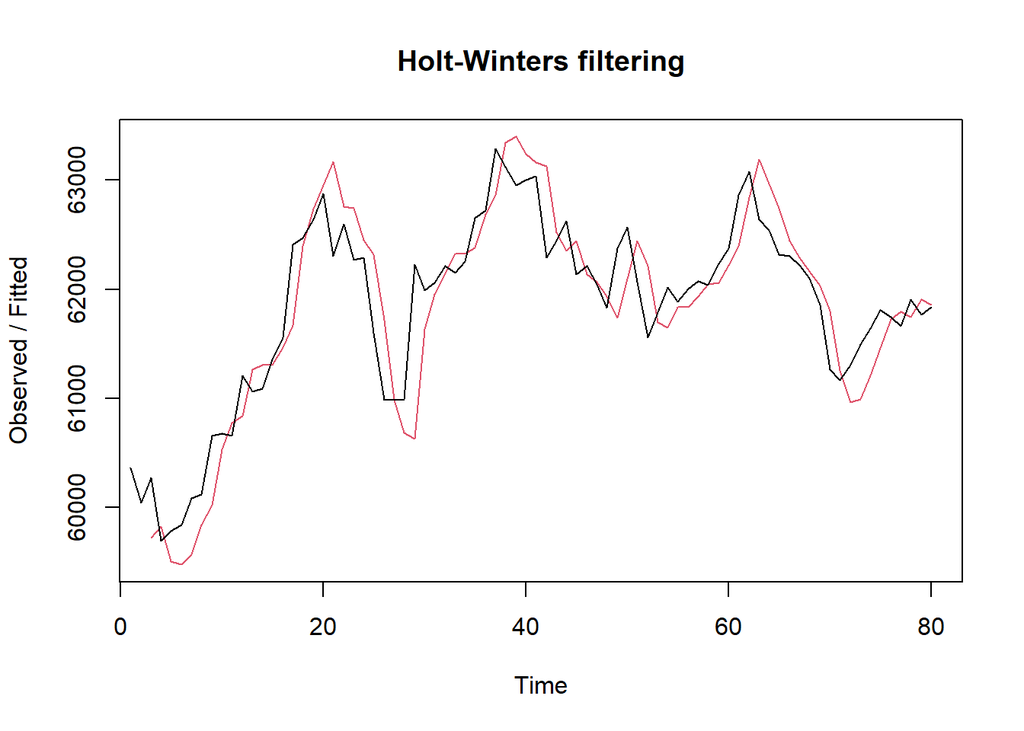

```r
#Lamda=0.6 dan gamma=0.3
des.2<- HoltWinters(train.ts, gamma = FALSE, beta = 0.3, alpha = 0.6)
plot(des.2)
```

```r
#ramalan
ramalandes2<- forecast(des.2, h=10)
ramalandes2
```

```
##    Point Forecast    Lo 80    Hi 80    Lo 95    Hi 95
## 81       61881.16 61376.20 62386.12 61108.89 62653.43
## 82       61914.77 61274.36 62555.17 60935.35 62894.18
## 83       61948.37 61145.18 62751.57 60720.00 63176.75
## 84       61981.98 60993.80 62970.16 60470.69 63493.27
## 85       62015.59 60823.62 63207.56 60192.63 63838.55
## 86       62049.20 60636.93 63461.47 59889.31 64209.08
## 87       62082.80 60435.33 63730.28 59563.20 64602.40
## 88       62116.41 60220.01 64012.81 59216.12 65016.71
## 89       62150.02 59991.90 64308.14 58849.45 65450.58
## 90       62183.63 59751.72 64615.53 58464.35 65902.91
```

Selanjutnya jika ingin membandingkan plot data latih dan data uji adalah sebagai berikut.

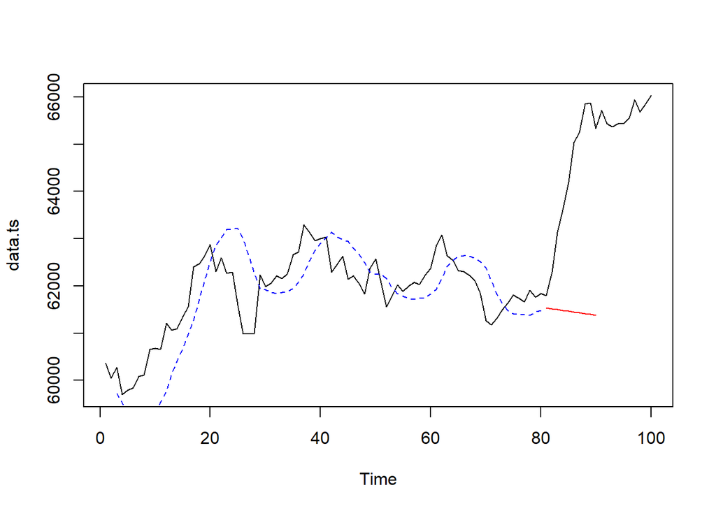

```r
plot(data.ts)
lines(des.1$fitted[,1], lty=2, col="blue")
lines(ramalandes1$mean, col="red")
```

Untuk mendapatkan nilai parameter optimum dari DES, argumen `alpha` dan `beta` dapat dibuat `NULL` seperti berikut.

```r
#Lamda dan gamma optimum
des.opt<- HoltWinters(train.ts, gamma = FALSE)
des.opt
```

```
## Holt-Winters exponential smoothing with trend and without seasonal component.
##
## Call:
## HoltWinters(x = train.ts, gamma = FALSE)
##
## Smoothing parameters:
##  alpha: 1
##  beta : 0.1321551
##  gamma: FALSE
##
## Coefficients:
##          [,1]
## a 61839.00000
## b     4.48549
```

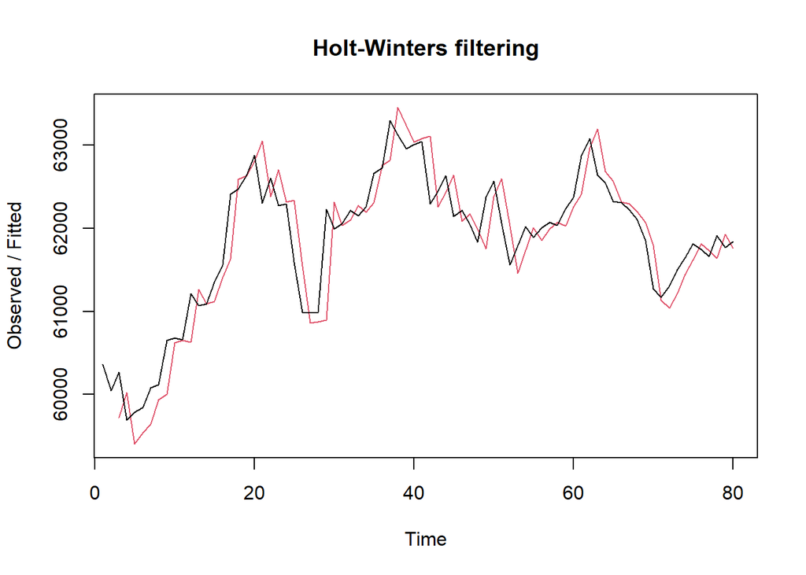

```r
plot(des.opt)
```

```r
#ramalan
ramalandesopt<- forecast(des.opt, h=10)
ramalandesopt
```

```
##    Point Forecast    Lo 80    Hi 80    Lo 95    Hi 95
## 81       61843.49 61382.58 62304.39 61138.59 62548.38
## 82       61847.97 61151.74 62544.20 60783.18 62912.76
## 83       61852.46 60944.54 62760.37 60463.92 63240.99
## 84       61856.94 60744.02 62969.86 60154.88 63559.00
## 85       61861.43 60544.24 63178.62 59846.96 63875.89
## 86       61865.91 60342.46 63389.37 59535.99 64195.84
## 87       61870.40 60137.24 63603.55 59219.77 64521.03
## 88       61874.88 59927.81 63821.96 58897.09 64852.68
## 89       61879.37 59713.69 64045.05 58567.24 65191.50
## 90       61883.85 59494.61 64273.10 58229.82 65537.89
```

Selanjutnya akan dilakukan perhitungan akurasi pada data latih maupun data uji dengan ukuran akurasi SSE, MSE dan MAPE.

#### Akurasi Data Latih

```r
#Akurasi Data Training
ssedes.train1<-des.1$SSE
msedes.train1<-ssedes.train1/length(train.ts)
sisaandes1<-ramalandes1$residuals
head(sisaandes1)
```

```
## Time Series:
## Start = 1
## End = 6
## Frequency = 1
## [1]       NA       NA 550.0000 166.0000 514.1600 743.1216
```

```r
mapedes.train1 <- sum(abs(sisaandes1[3:length(train.ts)]/train.ts[3:length(train.ts)])
                      *100)/length(train.ts)

akurasides.1 <- matrix(c(ssedes.train1,msedes.train1,mapedes.train1))
row.names(akurasides.1)<- c("SSE", "MSE", "MAPE")
colnames(akurasides.1) <- c("Akurasi lamda=0.2 dan gamma=0.2")
akurasides.1
```

```
##      Akurasi lamda=0.2 dan gamma=0.2
## SSE                     4.218962e+07
## MSE                     5.273703e+05
## MAPE                    9.531008e-01
```

```r
ssedes.train2<-des.2$SSE
msedes.train2<-ssedes.train2/length(train.ts)
sisaandes2<-ramalandes2$residuals
head(sisaandes2)
```

```
## Time Series:
## Start = 1
## End = 6
## Frequency = 1
## [1]        NA        NA  550.0000 -131.0000  282.1800  367.6596
```

```r
mapedes.train2 <- sum(abs(sisaandes2[3:length(train.ts)]/train.ts[3:length(train.ts)])
                      *100)/length(train.ts)

akurasides.2 <- matrix(c(ssedes.train2,msedes.train2,mapedes.train2))
row.names(akurasides.2)<- c("SSE", "MSE", "MAPE")
colnames(akurasides.2) <- c("Akurasi lamda=0.6 dan gamma=0.3")
akurasides.2
```

```
##      Akurasi lamda=0.6 dan gamma=0.3
## SSE                     1.200468e+07
## MSE                     1.500585e+05
## MAPE                    4.603327e-01
```

Hasil akurasi dari data latih didapatkan skenario 2 dengan lamda=0.6 dan gamma=0.3 memiliki hasil yang lebih baik. Namun untuk kedua skenario dapat dikategorikan peramalan sangat baik berdasarkan nilai MAPE-nya.

#### Akurasi Data Uji

```r
selisihdes1<-as.numeric(ramalandes1$mean) - as.numeric(testing$Price)
selisihdes1
```

```
##  [1]  -259.9440  -777.5434 -1636.1427 -2122.7421 -2727.3415 -3592.9409
##  [7] -3813.5403 -4431.1397 -4472.7391 -3951.3385 -4184.9440 -3919.5434
## [13] -3868.1427 -3946.7421 -3965.3415 -4106.9409 -4506.5403 -4270.1397
## [19] -4462.7391 -4644.3385
```

```r
SSEtestingdes1<-sum(selisihdes1^2)
MSEtestingdes1<-SSEtestingdes1/length(testing$Price)
MAPEtestingdes1<-sum(abs(selisihdes1/testing$Price)*100)/length(testing$Price)
```

```r
selisihdes2<-as.numeric(ramalandes2$mean) - as.numeric(testing$Price)
selisihdes2
```

```
##  [1]    89.15965  -378.23306 -1186.62577 -1623.01848 -2177.41120 -2992.80391
##  [7] -3163.19662 -3730.58933 -3721.98205 -3150.37476 -3835.84035 -3520.23306
## [13] -3418.62577 -3447.01848 -3415.41120 -3506.80391 -3856.19662 -3569.58933
## [19] -3711.98205 -3843.37476
```

```r
SSEtestingdes2<-sum(selisihdes2^2)
MSEtestingdes2<-SSEtestingdes2/length(testing$Price)
MAPEtestingdes2<-sum(abs(selisihdes2/testing$Price)*100)/length(testing$Price)
```

```r
selisihdesopt<-as.numeric(ramalandesopt$mean)-as.numeric(testing$Price)
selisihdesopt
```

```
##  [1]    51.48549  -445.02902 -1282.54353 -1748.05804 -2331.57255 -3176.08706
##  [7] -3375.60157 -3972.11608 -3992.63059 -3450.14510 -3873.51451 -3587.02902
## [13] -3514.54353 -3572.05804 -3569.57255 -3690.08706 -4068.60157 -3811.11608
## [19] -3982.63059 -4143.14510
```

```r
SSEtestingdesopt<-sum(selisihdesopt^2)
MSEtestingdesopt<-SSEtestingdesopt/length(testing$Price)
MAPEtestingdesopt<-sum(abs(selisihdesopt/testing$Price)*100)/length(testing$Price)
```

```r
akurasitestingdes <-
  matrix(c(SSEtestingdes1,MSEtestingdes1,MAPEtestingdes1,SSEtestingdes2,MSEtestingdes2,
           MAPEtestingdes2,SSEtestingdesopt,MSEtestingdesopt,MAPEtestingdesopt),
         nrow=3,ncol=3)
row.names(akurasitestingdes)<- c("SSE", "MSE", "MAPE")
colnames(akurasitestingdes) <- c("des ske1","des ske2","des opt")
akurasitestingdes
```

```
##          des ske1     des ske2      des opt
## SSE  2.740350e+08 1.963923e+08 2.188883e+08
## MSE  1.370175e+07 9.819616e+06 1.094441e+07
## MAPE 5.328038e+00 4.459269e+00 4.711567e+00
```

#### Perbandingan SES dan DES

```r
MSEfull <-
  matrix(c(MSEtesting1,MSEtesting2,MSEtestingopt,MSEtestingdes1,MSEtestingdes2,
           MSEtestingdesopt),nrow=3,ncol=2)
row.names(MSEfull)<- c("ske 1", "ske 2", "ske opt")
colnames(MSEfull) <- c("ses","des")
MSEfull
```

```
##             ses      des
## ske 1   8032956 13701751
## ske 2   7768029  9819616
## ske opt 7696044 10944415
```

## Kesimpulan

Namun, jika dibandingkan secara keseluruhan, metode SES menunjukkan nilai MSE yang lebih rendah dibandingkan DES pada semua skenario, yang berarti SES memiliki presisi peramalan yang lebih baik terhadap data uji. Dengan demikian, dapat disimpulkan bahwa metode SES lebih sesuai digunakan untuk data ini, sementara pada metode DES, skenario 2 merupakan pilihan yang paling akurat.

Berikut kesimpulan singkatnya kenapa SES lebih baik dibanding DES pada data ini :

1. Tren data tidak konsisten/stabil → DES sulit menangkap pola.
2. Parameter DES (λ, γ) belum optimal → bisa menyebabkan error lebih besar.
3. Horizon ramalan pendek → tren kurang berpengaruh, SES lebih stabil.
4. Data lebih didominasi fluktuasi (noise) → model sederhana (SES) justru lebih akurat.